# Univariate EDA

Dynasty

2022-07-14

```r
knitr::opts_chunk$set(echo = TRUE)
```

# Univariate Graphical Exploratory Data Analysis

## 1. Measures of Central Tendency

Before embarking on developing statistical models and generating predictions, it is essential to understand our data. This is typically done using conventional numerical and graphical methods.

We will be using the hills dataset, this dataset contains information on hill climbs made by various athletes

```r
library(MASS)
head(hills)
```

```
##              dist climb   time
## Greenmantle   2.5   650 16.083
## Carnethy      6.0  2500 48.350
## Craig Dunain  6.0   900 33.650
## Ben Rha       7.5   800 45.600
## Ben Lomond    8.0  3070 62.267
## Goatfell      8.0  2866 73.217
```

Rows and columns

```r
dim(hills)
```

```
## [1] 35  3
```

#### Mean Code Example 1.1

Find the mean of the distance covered by the athletes and assigning the mean to the variable athletes.dist.mean

```r
athletes.dist.mean <- mean(hills$dist)
athletes.dist.mean
```

```
## [1] 7.528571
```

The mean distance covered is 7.528571

#### Median Code Example 1.2

Finding the median which is the middle most value of the distance covered dist

```r
athletes.dist.median <- median(hills$dist)
athletes.dist.median
```

```
## [1] 6
```

The meadian is 6

#### Mode Code Example 1.3

Find the mode which is the value that has highest number of occurrences in a set of data.

Unfotunately, R does not have a standard in-built function to calculate mode so we have to build one, We create the mode function that will perform our mode operation for us

```r
getmode <- function(v) {
   uniqv <- unique(v)
   uniqv[which.max(tabulate(match(v, uniqv)))]
}
```

Now we Calculate the mode using out getmode() function

```r
athletes.dist.mode <- getmode(hills$dist)
athletes.dist.mode
```

```
## [1] 6
```

##### Let’s Challenge Ourselves

Dataset url = http://bit.ly/CustomerSignatureforChurnAnalysis

```r
library(data.table)
churn <- fread('http://bit.ly/CustomerSignatureforChurnAnalysis')
head(churn)
```

```
##    recordID state account_length area_code international_plan voice_mail_plan
## 1:        1    HI            101       510                 no              no
## 2:        2    MT            137       510                 no              no
## 3:        3    OH            103       408                 no             yes
## 4:        4    NM             99       415                 no              no
## 5:        5    SC            108       415                 no              no
## 6:        6    IA            117       415                 no              no
##    number_vmail_messages total_day_minutes total_day_calls total_day_charge
## 1:                     0              70.9             123            12.05
## 2:                     0             223.6              86            38.01
## 3:                    29             294.7              95            50.10
## 4:                     0             216.8             123            36.86
## 5:                     0             197.4              78            33.56
## 6:                     0             226.5              85            38.51
##    total_eve_minutes total_eve_calls total_eve_charge total_night_minutes
```

[output cut: 20 more lines]

Let’s see number of rows and columns

```r
dim(churn)
```

```
## [1] 12892    22
```

#### **Data cleaning**

Let’s do some data cleaning

**Checking for Missing values**

```r
is.null(churn)
```

```
## [1] FALSE
```

We don’t have null values.

**Checking for Duplicates**

```r
churn_duplicated <- churn[duplicated(churn),]
churn_duplicated
```

```
##        recordID state account_length area_code international_plan
##     1:        2    MT            137       510                 no
##     2:        3    OH            103       408                 no
##     3:        4    NM             99       415                 no
##     4:        5    SC            108       415                 no
##     5:        6    IA            117       415                 no
##    ---
## 12886:    12888    MT             25       415                 no
## 12887:    12889    MT            113       415                 no
## 12888:    12890    ID             88       415                 no
## 12889:    12891    AK            120       415                 no
## 12890:    12892    UT             74       415                 no
##        voice_mail_plan number_vmail_messages total_day_minutes total_day_calls
##     1:              no                     0             223.6              86
##     2:             yes                    29             294.7              95
```

[output cut: 57 more lines]

```r
unique(churn)
```

```
##        recordID state account_length area_code international_plan
##     1:        1    HI            101       510                 no
##     2:        2    MT            137       510                 no
##     3:        3    OH            103       408                 no
##     4:        4    NM             99       415                 no
##     5:        5    SC            108       415                 no
##    ---
## 12888:    12888    MT             25       415                 no
## 12889:    12889    MT            113       415                 no
## 12890:    12890    ID             88       415                 no
## 12891:    12891    AK            120       415                 no
## 12892:    12892    UT             74       415                 no
##        voice_mail_plan number_vmail_messages total_day_minutes total_day_calls
##     1:              no                     0              70.9             123
##     2:              no                     0             223.6              86
```

[output cut: 57 more lines]

**Checking for Outliers**

```r
library("ggplot2")                                           # Load ggplot2
```

We will focus on the numeric columns

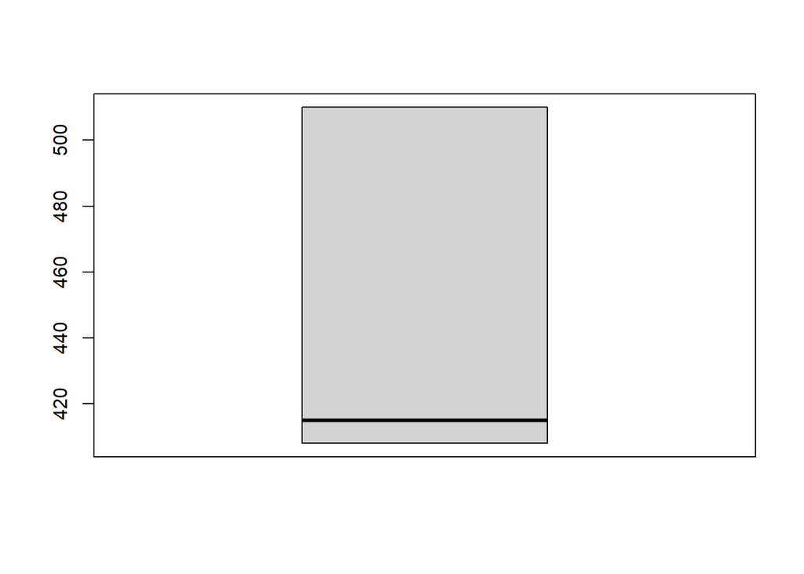

```r
boxplot(churn$area_code)
```

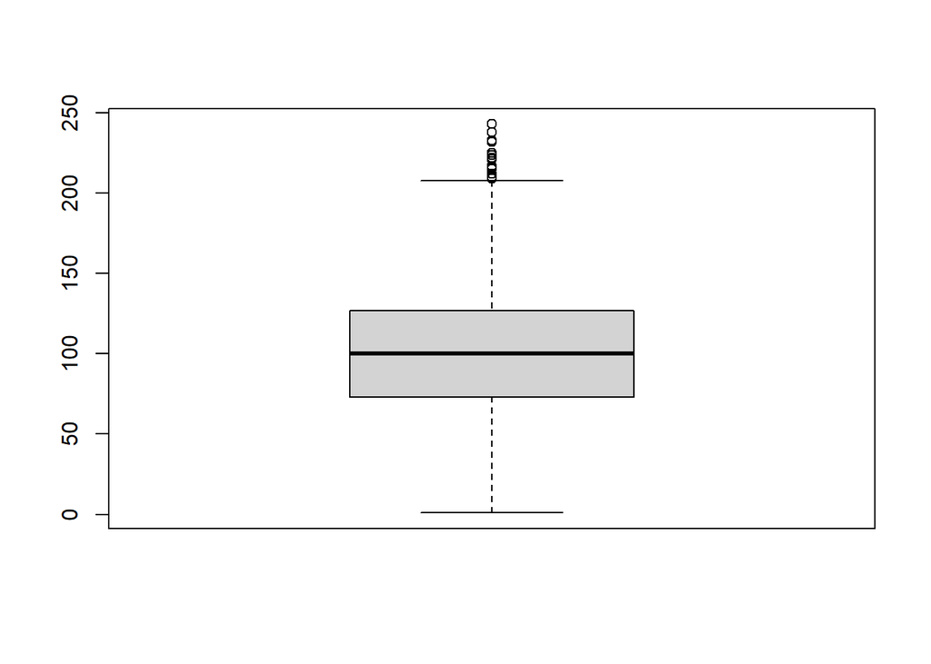

```r
boxplot(churn$account_length)
```

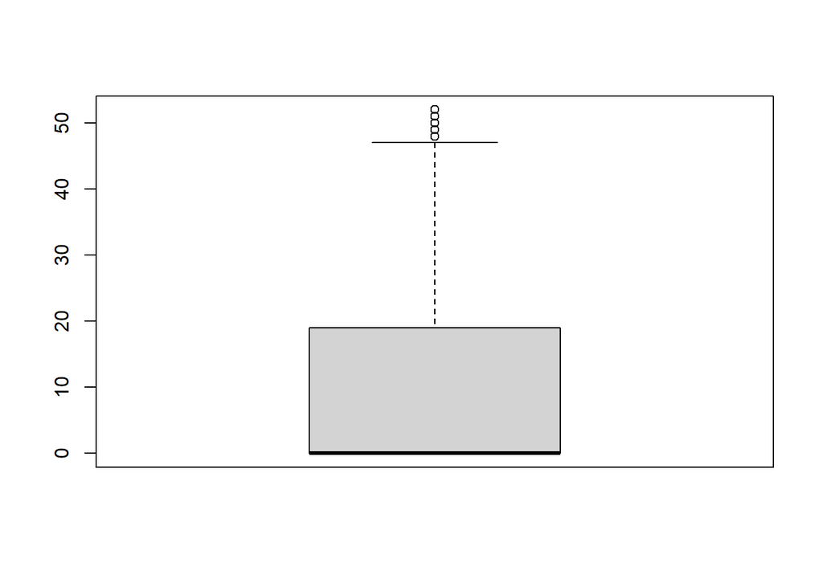

```r
boxplot(churn$number_vmail_messages)
```

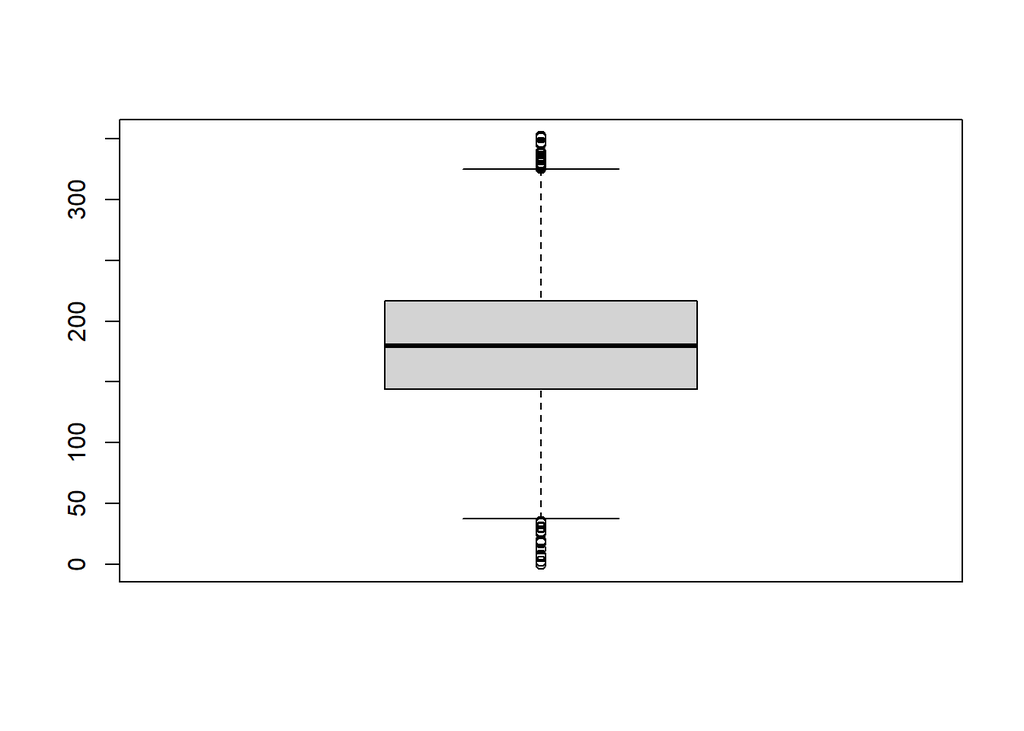

```r
boxplot(churn$total_day_minutes)
```

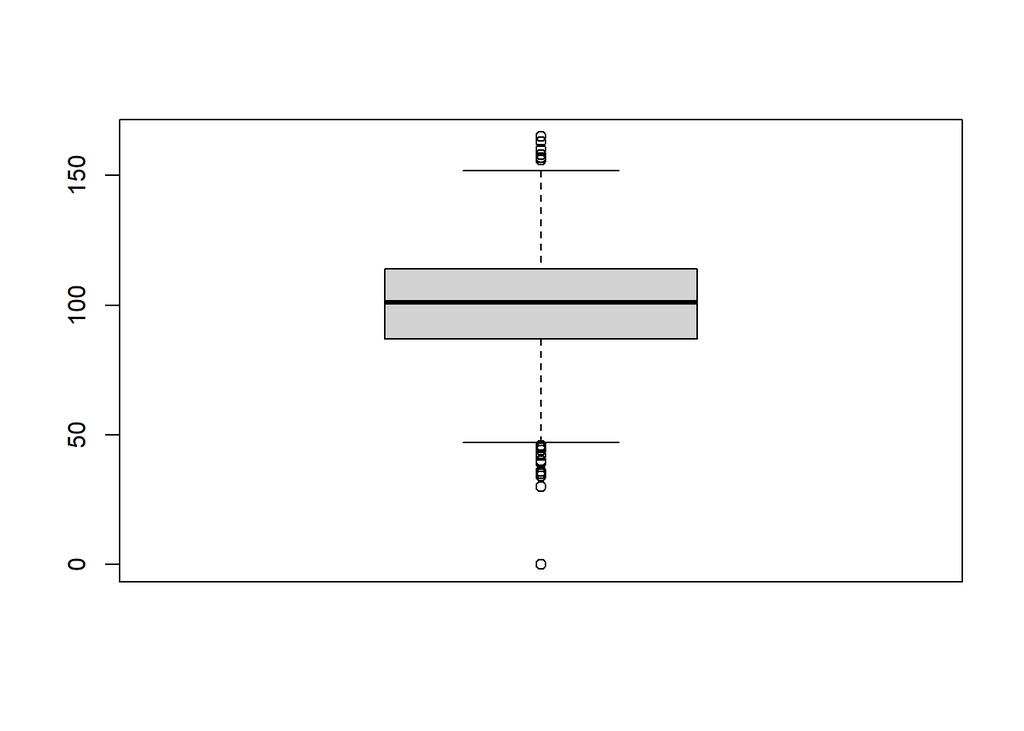

```r
boxplot(churn$total_day_calls)
```

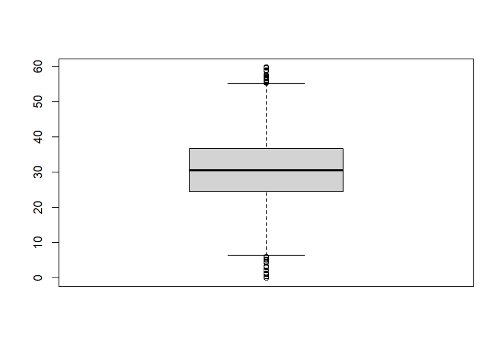

```r
boxplot(churn$total_day_charge)
```

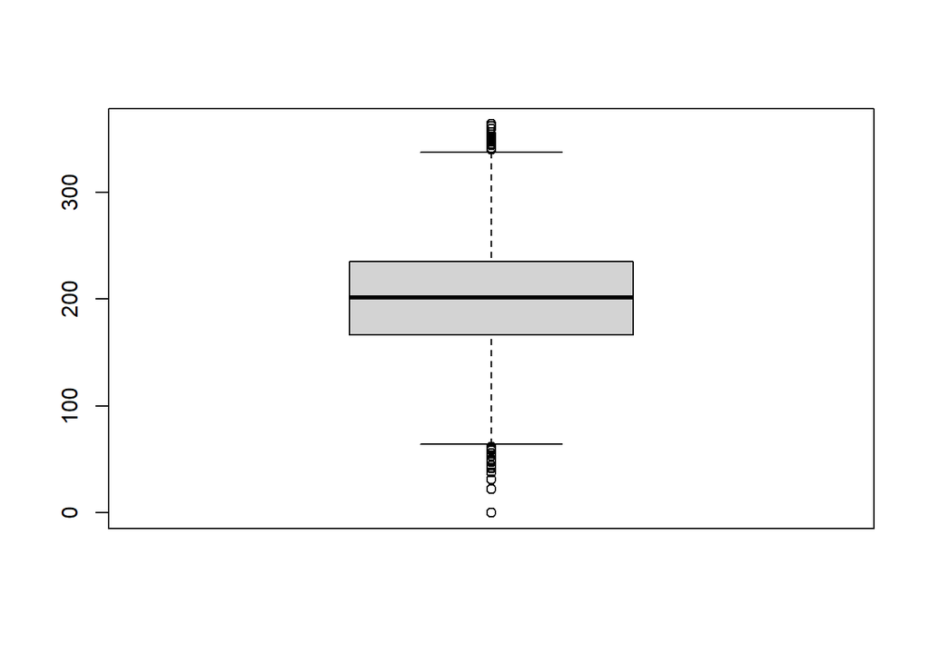

```r
boxplot(churn$total_eve_minutes)
```

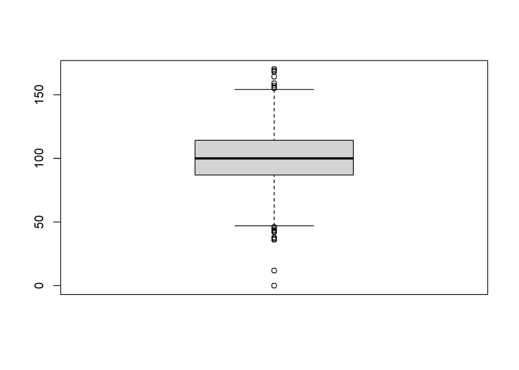

```r
boxplot(churn$total_eve_calls)
```

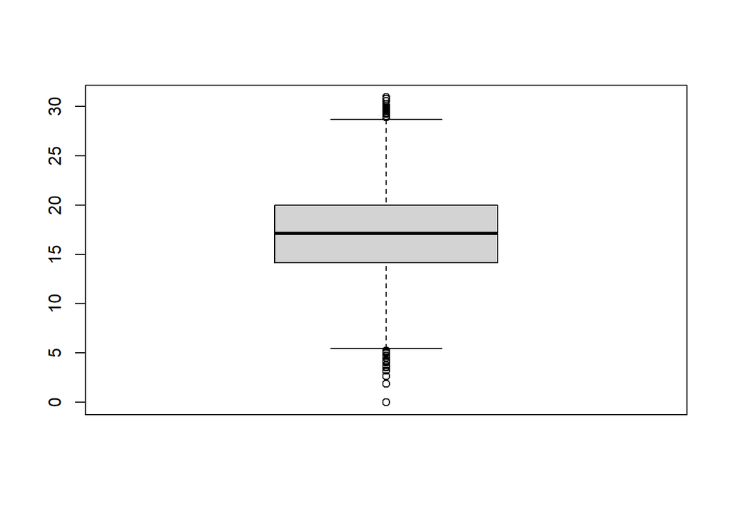

```r
boxplot(churn$total_eve_charge)
```

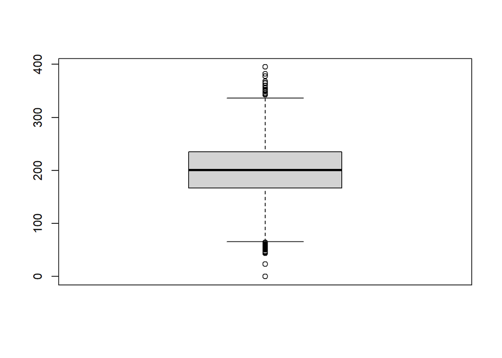

```r
boxplot(churn$total_night_minutes)
```

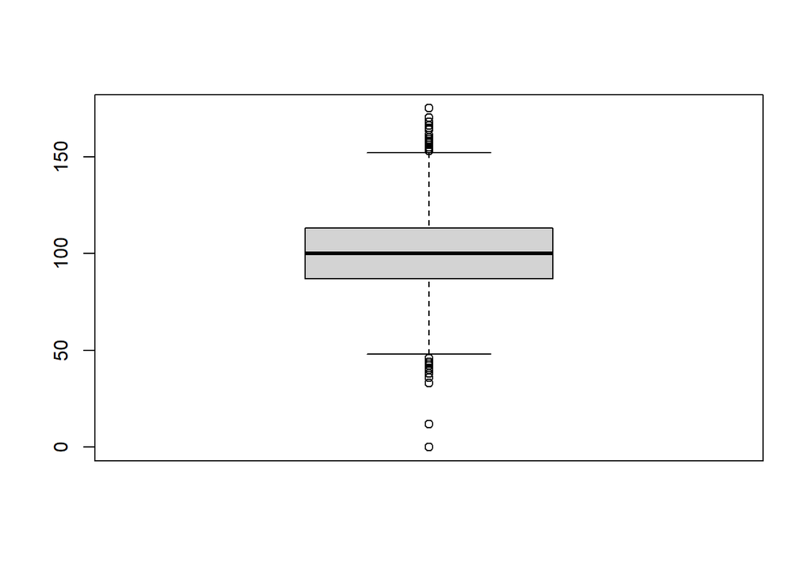

```r
boxplot(churn$total_night_calls)
```

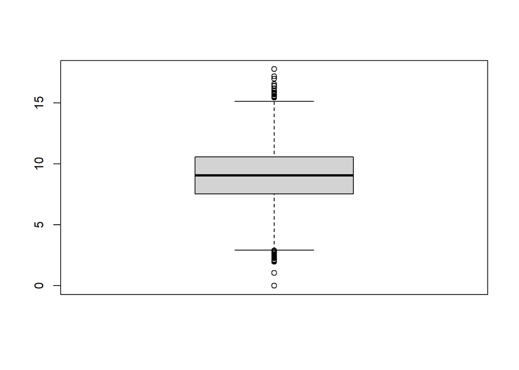

```r
boxplot(churn$total_night_charge)
```

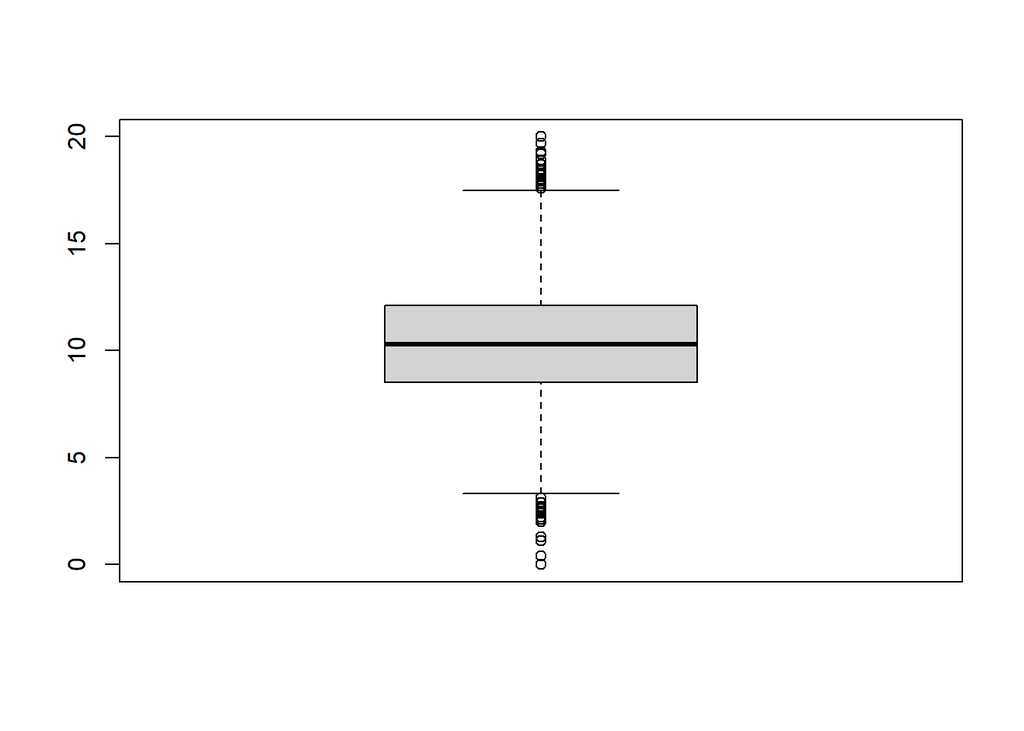

```r
boxplot(churn$total_intl_minutes)
```

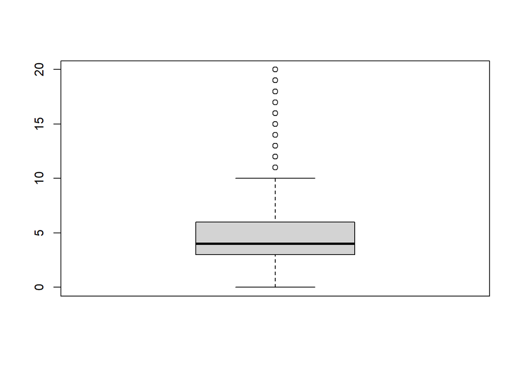

```r
boxplot(churn$total_intl_calls)
```

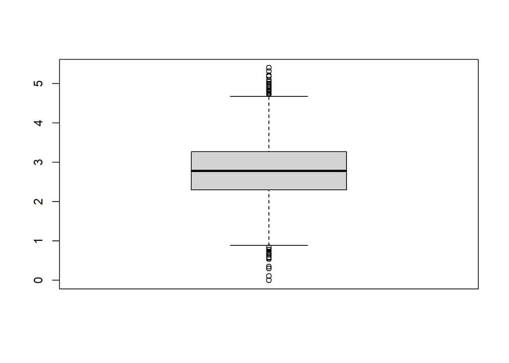

```r
boxplot(churn$total_intl_charge)
```

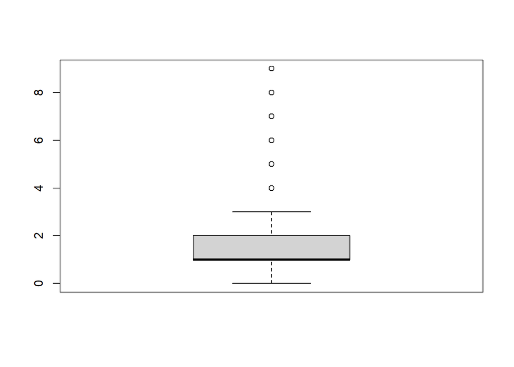

```r
boxplot(churn$number_customer_service_calls)
```

we have some columns with outliers

### **Questions**

**Find the minimum of total day calls**

```r
churn.dist.min <- min(churn$total_day_calls)
churn.dist.min
```

```
## [1] 0
```

**Find the maximum i.e. max() total day calls**

```r
churn.dist.max <- max(churn$total_day_calls)
churn.dist.max
```

```
## [1] 165
```

**Find the range i.e. range() of total day calls**

```r
churn.dist.range <- range(churn$total_day_calls)
churn.dist.range
```

```
## [1]   0 165
```

**Find the quantile of total day calls**

```r
churn.dist.quantile <- quantile(churn$total_day_calls)
churn.dist.quantile
```

```
##   0%  25%  50%  75% 100%
##    0   87  101  114  165
```

**Find the variance of total day calls**

```r
churn.dist.variance <- var(churn$total_day_calls)
churn.dist.variance
```

```
## [1] 397.8691
```

**Find the standard deviation of total day calls**

```r
churn.dist.sd <- sd(churn$total_day_calls)
churn.dist.sd
```

```
## [1] 19.94666
```

## **3. Univariate Graphical**

#### Box Plots Code Example 3.1

Lets create a boxplot graph for the distance using the boxplot() function

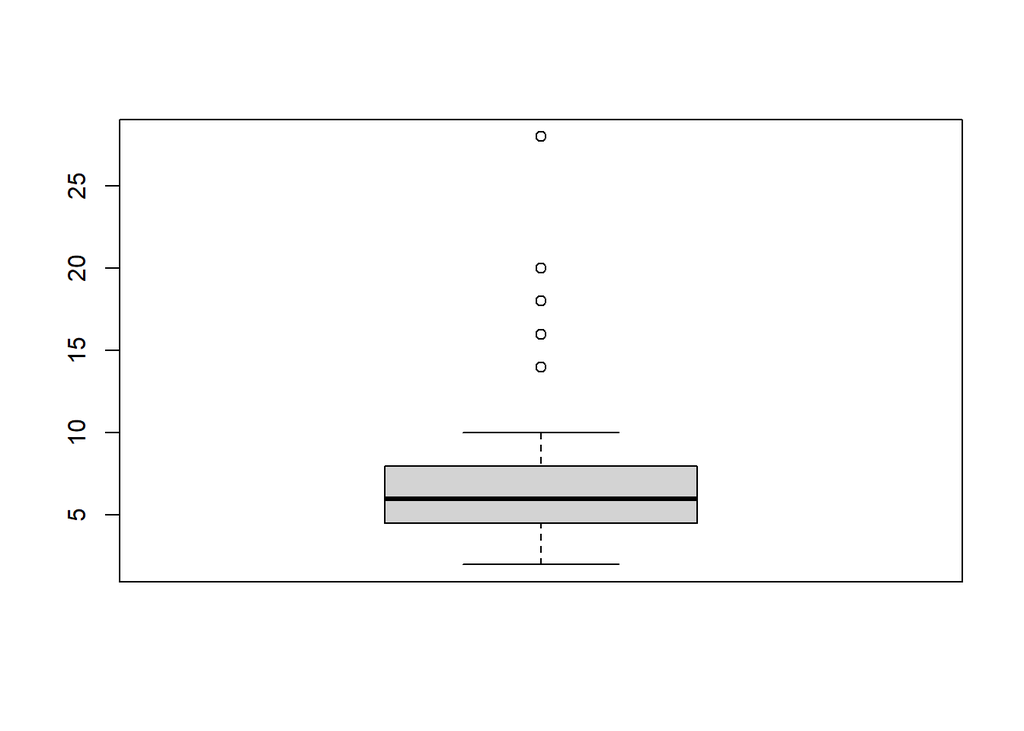

```r
boxplot(hills$dist)
```

The box plot of an observation variable is a graphical representation based on its quartiles, as well as its smallest and largest values. It attempts to provide a visual shape of the data distribution.

A bar graph of a qualitative data sample consists of vertical parallel bars that shows the frequency distribution graphically.

Let’s Create a frequency distribution of the School variable using an R built-in database named painters

```r
head(painters)
```

```
##               Composition Drawing Colour Expression School
## Da Udine               10       8     16          3      A
## Da Vinci               15      16      4         14      A
## Del Piombo              8      13     16          7      A
## Del Sarto              12      16      9          8      A
## Fr. Penni               0      15      8          0      A
## Guilio Romano          15      16      4         14      A
```

```r
dim(painters)
```

```
## [1] 54  5
```

First Fetch the school column

```r
school <- painters$School
```

When we apply the table() function will compute the frequency distribution of the School variable

```r
school_frequency <- table(school)
school_frequency
```

```
## school
##  A  B  C  D  E  F  G  H
## 10  6  6 10  7  4  7  4
```

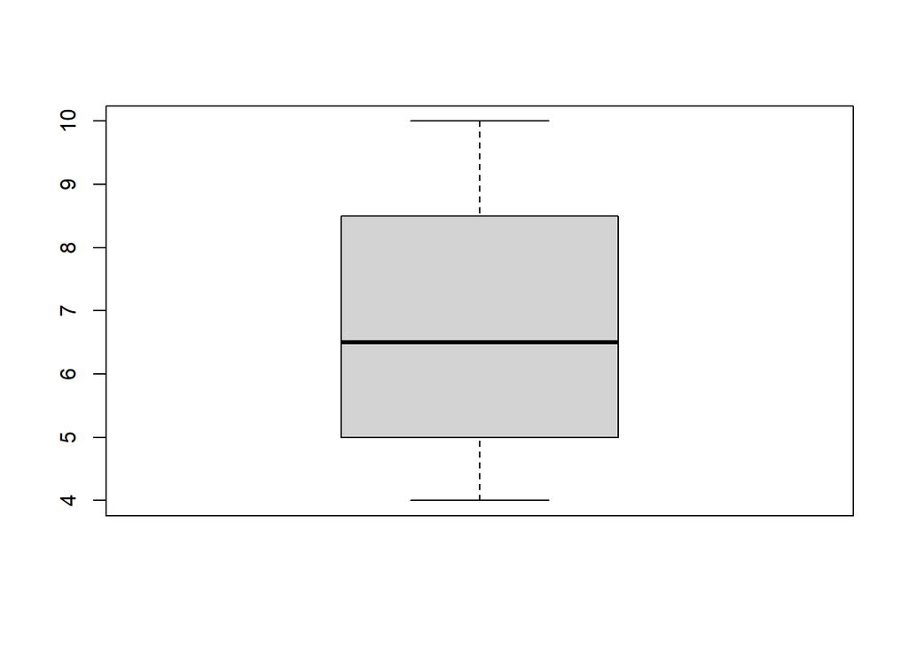

```r
boxplot(school_frequency)
```

##### **Challenge**

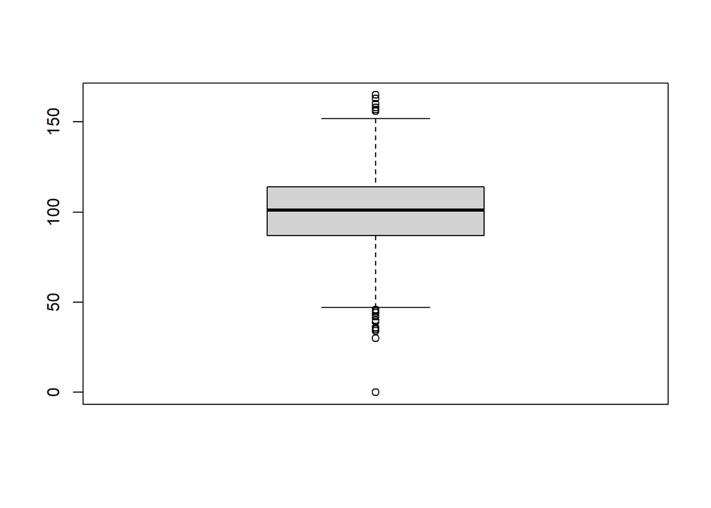

```r
boxplot(churn$total_day_calls)
```

#### **Histogram Code Example 3.3**

A histogram shows the frequency distribution of a quantitative variable. The area of each bar is equal to the frequency of items found in each class.

Will Create a histogram using the faithful dataset

```r
head(faithful)
```

```
##   eruptions waiting
## 1     3.600      79
## 2     1.800      54
## 3     3.333      74
## 4     2.283      62
## 5     4.533      85
## 6     2.883      55
```

Then applying the hist() function to produce the histogram of the eruptions variable

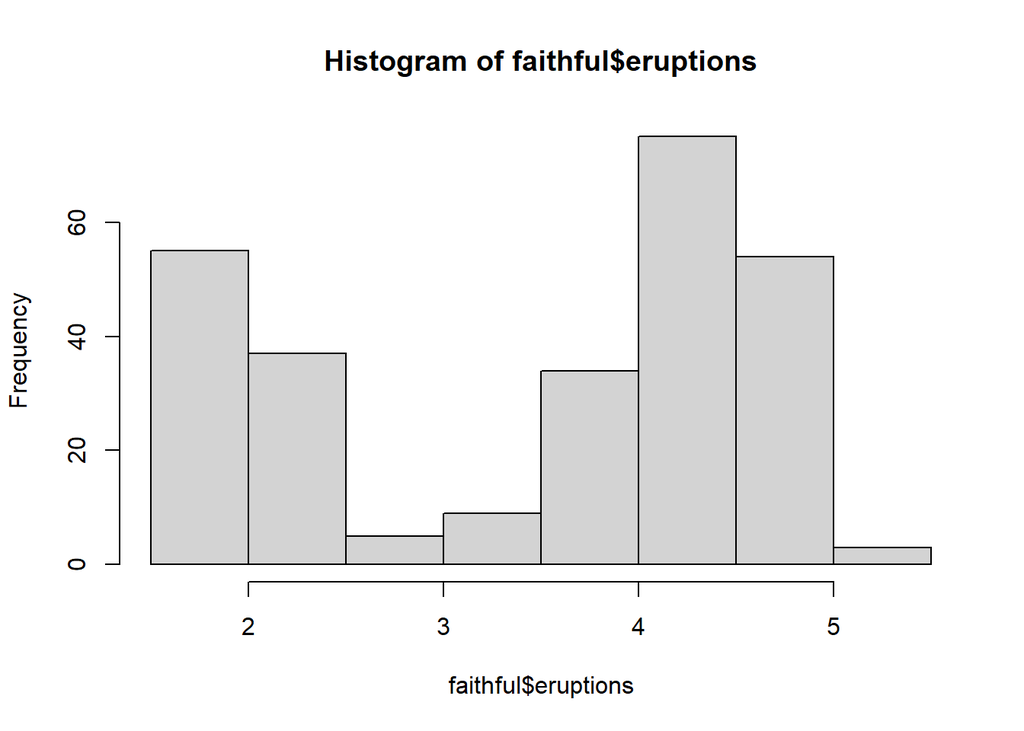

```r
hist(faithful$eruptions)
```

Now let’s Create a histogram of the total day minutes in the customer signature dataset

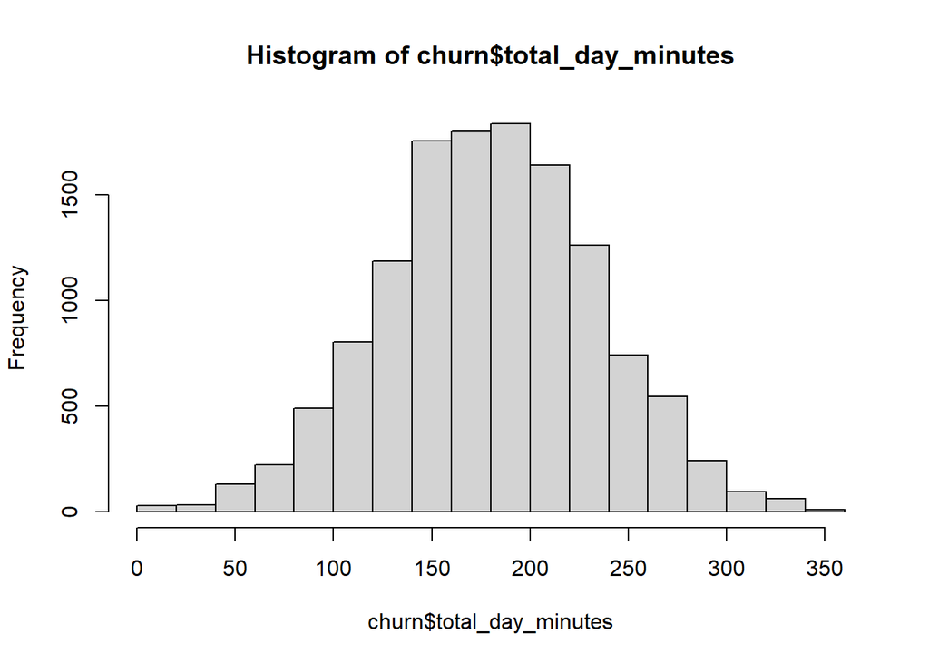

```r
hist(churn$total_day_minutes)
```

Let’s have more fun with the churn data set

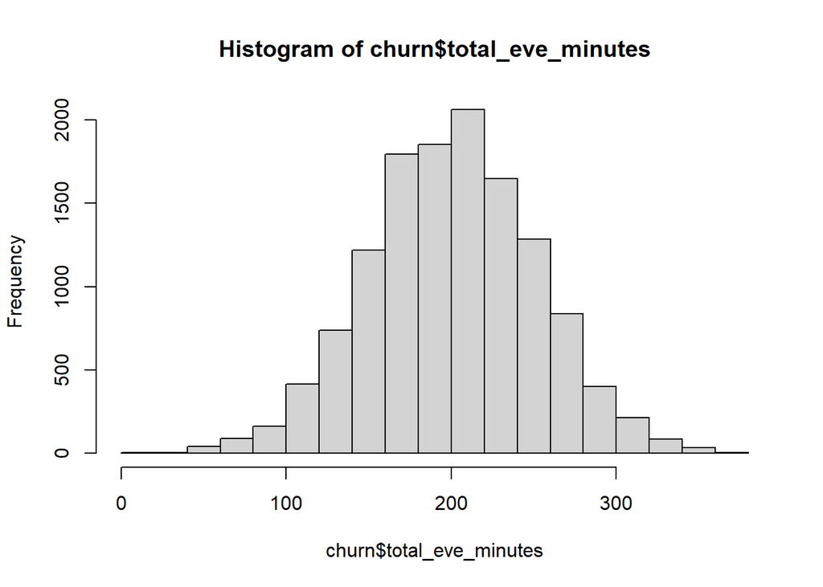

```r
hist(churn$total_eve_minutes)
```

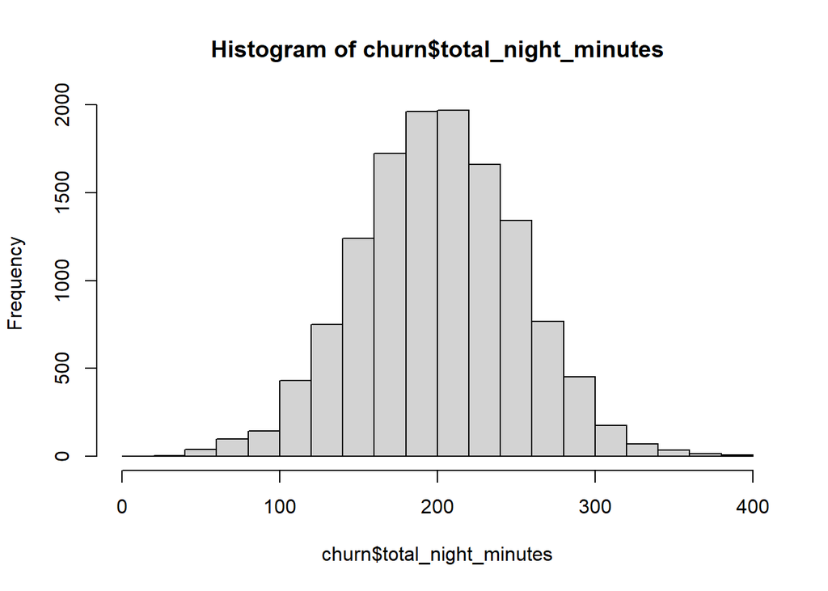

```r
hist(churn$total_night_minutes)
```

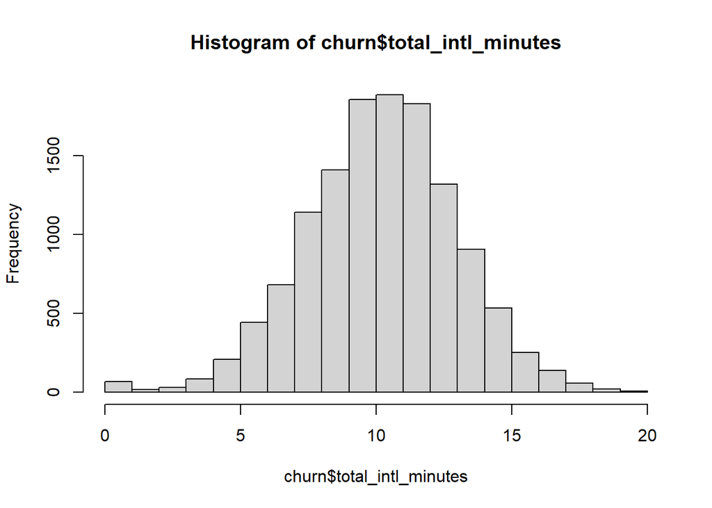

```r
hist(churn$total_intl_minutes)
```

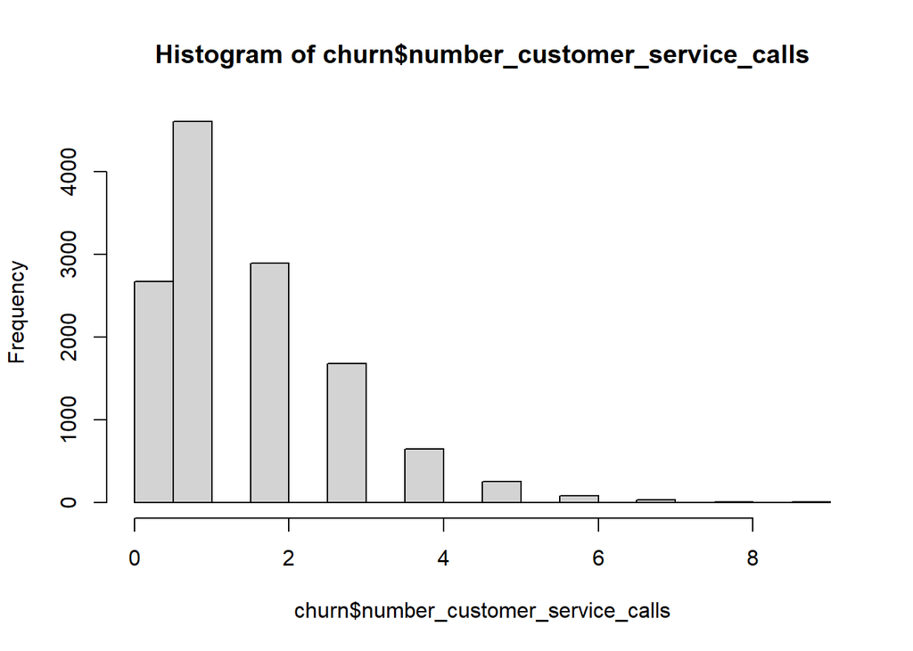

```r
hist(churn$number_customer_service_calls)
```

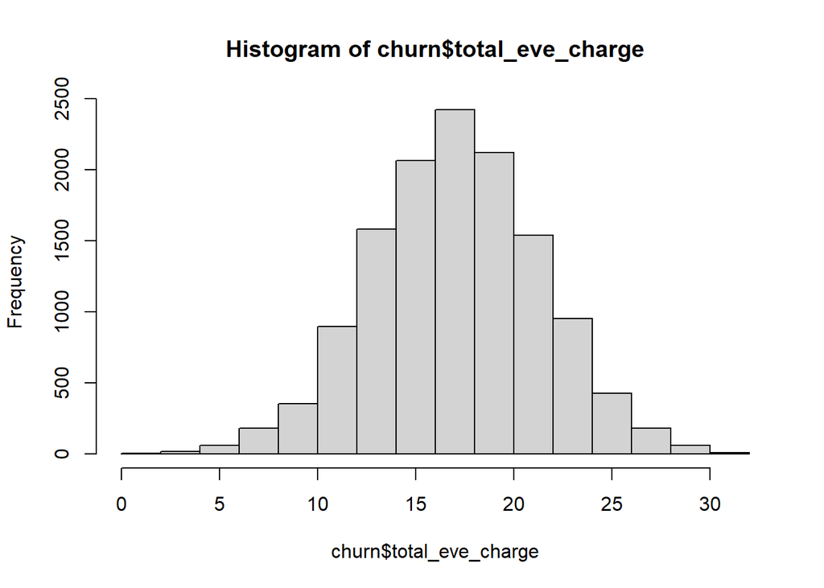

```r
hist(churn$total_eve_charge)
```

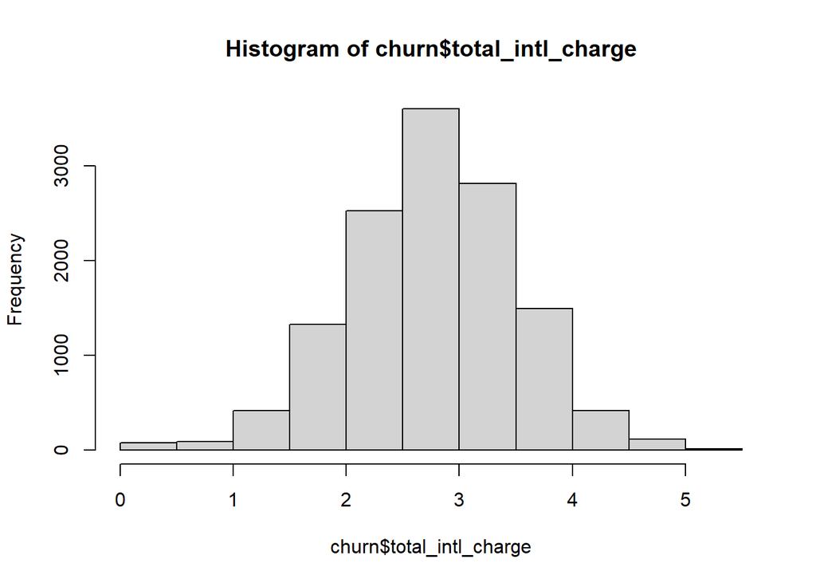

```r
hist(churn$total_intl_charge)
```

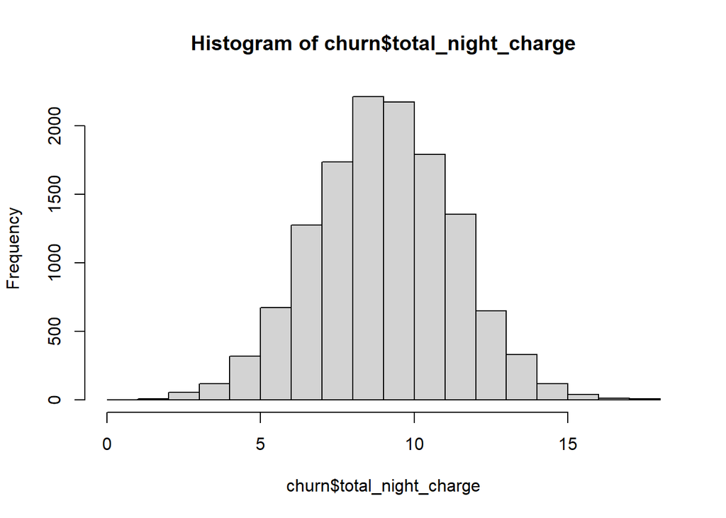

```r
hist(churn$total_night_charge)
```